# Spending Habits

Christopher Eshleman

5/18/2019

## Spending habits

I’m going to try and understand my spending habits through exploratory work. A sidecar goal is to find ways to reduce personal spending by 5 percent over the next two years. But first things first.

I went to my bank and credit card websites and figured out how to download spending histories. I could go way back with my checking account / debit card, but only four months or so for my two credit cards.

```r
cat("\014") # clear the console
```

```r
rm(list=ls())
dev.off()
```

```r
check = read.csv("~/Dropbox/Home/Financial/spending/Checking1.csv", header=F)
names(check) = c("date","amt","na","check_no","desc")
check$card = "debit"

cc1 = read.csv("~/Dropbox/Home/Financial/spending/CreditCard4.csv", header=F)
names(cc1) = c("date","amt","na","check_no","desc")
cc1$card = "cardWF"

dat = rbind(check,cc1)
dat$na = NULL
dat$check_no = NULL
```

So I’ll combine the first file (checking/debit) with my first credit card. Then I’ll read in the second card, which is from a different institution, and reshape it to match the format from teh first two. Then I’ll be able to mash all three together.

```r
cc2 = read.csv("~/Dropbox/Home/Financial/spending/bk_download.csv", header=F)
cc2$card = "cardUS"
cc2 = cc2[, c(3,7,5,8)]
names(cc2) = c("date","amt","desc","card")

dat = rbind(dat,cc2)

rm(cc1,cc2,check)

dat$date = as.Date(dat$date, format="%m/%d/%Y")  #recognizes this variable as a date.
```

Since only one of them includes dates back to the beginning of 2018, I’ll chop off everything before February of this year. That’ll give me three and a half months to get started with.

```r
dat = subset(dat,dat$date>"2019-01-31")
```

## Spending

I want to know how I spend money by category or type. Groceries versus movie rentals (mostly on Google Play), for example.

First, some basic stuff. Do I use some cards for bigger purchases than others?

```r
spend = subset(dat,dat$amt<0 & dat$amt>-1200) #Limit to spending, not deposits or payments
spend$amount = -(spend$amt) #Make it positive
summary(spend$amount)
```

```
##    Min. 1st Qu.  Median    Mean 3rd Qu.    Max.
##    0.25    5.81   14.95   42.85   39.00  912.97
```

I focused on spending, not deposits or payments. And I knocked out a one-time big-ticket item that shouldn’t count as part of my personal spending, as well as monthly rent.

I have so much spending that falls into the few-dollar range, I’ll take the log of spending for graphing purposes.

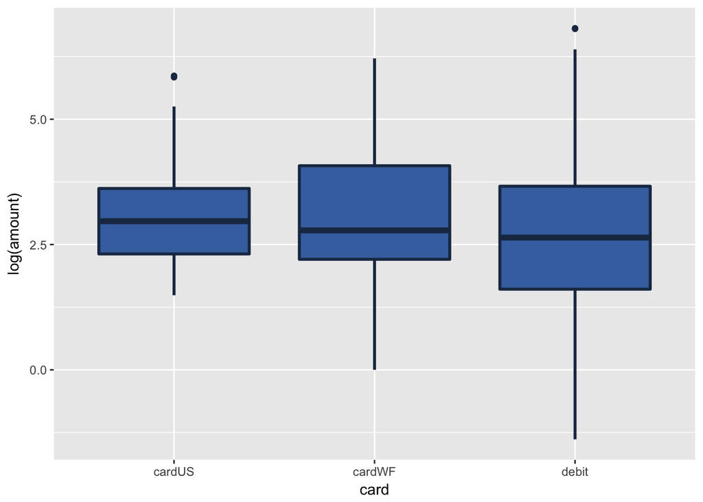

Yep, looks like I’ve been using my “US” credit card for slightly larger purposes. I wonder why that is … it’s the most recent card I got.

More to come here …

(Note that the `echo = FALSE` parameter was added to the code chunk to prevent printing of the R code that generated the plot.)